# PS04

`Due: 2023-05-30 11:59 PST`

## README

Complete the following questions below and show all work. You must submit a compiled R report with all code and answers in this document. Compile the report to html or PDF and submit on Canvas. html is preferred. Make sure to write your name above where it says “WRITE YOUR NAME HERE”. Include it within the quotation marks.

Before writing answering the following questions, make sure to compile the report to make sure that everything is working properly. As you answer each question, compile after each question to make sure you are not making any errors. If you are experiencing an error, read the error carefully. One tactic is to selectively delete questions/sections until the report compiles. This will help you narrow down where the coding error is occuring.

#### Data

The data from this problem set are a sample of district level data from the state of Massachusetts in 1998. It can be loaded into memory through installing the `AER` package from CRAN (i.e., `install.packages("AER")`).

The Massachusetts data are district-wide averages for public elementary school districts in 1998. The data analyzed here are the overall total score, which is the sum of the scores on the English, Math, and Science portions of the test. Data on the student-teacher ratio, the percent of students receiving a subsidized lunch and on the percent of students still learning english are averages for each elementary school district for the 1997–1998 school year and were obtained from the Massachusetts department of education. Data on average district income are from the 1990 US Census.

#### Integrity

If you are suspected of cheating, you will receive a zero—for the assignment and possibly for the course. Cheating includes copying work from your classmates, from the internet, and from previous problem sets. You are encouraged to work with your peers, but everyone must submit their own solutions.

## Setup

Load the required packages `tidyverse`, `broom`, and AER

*Solution*.

```r
pacman::p_load(tidyverse, broom, AER)
```

Load data with the following code `data("MASchools")`. Now an object named `MASchools` should be loaded into your R environment.[^1]

- Print the first 10 observations in the dataset by using the function `head()`.[^2]

*Solution*.

```r
data("MASchools")
# Rename dataset to something more palatable
school_df = MASchools
# Print the first 10 observations
school_df %>% head(10)
```

```
   district municipality expreg expspecial expbil expocc exptot scratio special
1         1     Abington   4201    7375.69      0      0   4646    16.6    14.6
2         2        Acton   4129    8573.99      0      0   4930     5.7    17.4
3         3     Acushnet   3627    8081.72      0      0   4281     7.5    12.1
4         5       Agawam   4015    8181.37      0      0   4826     8.6    21.1
5         7     Amesbury   4273    7037.22      0      0   4824     6.1    16.8
6         8      Amherst   5183   10595.80   6235      0   6454     7.7    17.2
7         9      Andover   4685   12279.58      0      0   5537     5.4    11.3
8        10    Arlington   5518   10055.05      0      0   6405     7.1    20.4
9        14      Ashland   5009    8840.86      0      0   5649    10.6    13.9
10       16    Attleboro   3823    9547.39  12943  11519   4814     6.7    13.2
   lunch stratio income score4 score8  salary   english
1   11.8    19.0 16.379    714    691 34.3600 0.0000000
2    2.5    22.6 25.792    731     NA 38.0630 1.2461059
3   14.1    19.3 14.040    704    693 32.4910 0.0000000
4   12.1    17.9 16.111    704    691 33.1060 0.3225806
5   17.4    17.5 15.423    701    699 34.4365 0.0000000
6   26.8    15.7 11.144    714     NA      NA 3.9215686
7    3.3    17.1 26.327    725    728 41.6150 0.0000000
8   11.2    16.8 21.449    717    715 36.9940 2.7027028
9    8.6    17.3 21.912    702    705 34.4215 0.0000000
10  20.7    20.5 14.970    701    688 33.8790 0.3752345
```

Read the documentation of the data by typing `?MASchools`. Describe in words what the following variables mean:

- `district`
- `municipality`
- `stratio`
- `score4`
- `exptot`
- `income`
- *Solution*.
- `district`: The district number
- `municipality`: The name of the municipality
- `stratio`: Student-teacher ratio.
- `score4`: 4th grade score (math + English + science).
- `expreg`: Expenditures per pupil, total

## Getting to know your data

The following functions help users look the data printed on the screen:

- `str`
- `glimpse`
- `View()`

Use one or all of these functions to solution the following.

- What observation level is the data at?
- What type of data is this (recall data types from the review lecture).

*Solution*. The data are at the district level. Meaning that each row describes a single district.

This is cross sectional data since each $i$ only has one observation

Use `dplyr` functions to answer the following questions about the data.

- How many different school districts/municipalities are there?
- Which municipality spends the most money on each child?
- Of the non-missing data, what is the average 4th grade test score? [^3]

*Solution*.

```r
# How many different school districts are there?
num_districts = nrow(school_df)

paste("The total question of districts (and municipalities) is ", num_districts)
```

```
[1] "The total question of districts (and municipalities) is  220"
```

```r
# Which municipality spends the most money on each child?
top_exp = school_df %>%
  mutate(max = max(expreg)) %>%
  filter(expreg == max) %>%
  select(municipality) %>%
  as.character

paste(top_exp, "is the biggest spender on their students")
```

```
[1] "Cambridge is the biggest spender on their students"
```

```r
# What is the average test score aggregated 8th grade test score?
mean_score4 = school_df %>%
  select(score4) %>%
  summarize(mean = mean(score4, na.rm = TRUE)) %>%
  as.numeric() %>%
  round(2)


paste("The mean, aggregated test score for 4th graders is ", mean_score4)
```

```
[1] "The mean, aggregated test score for 4th graders is  709.83"
```

Plot the histogram of test scores for 4th graders. Make it look nice by adding a title and labels to your axis. Maybe try to give it some color. If you would like, install the `ggthemes` package (`install.packages("ggthemes")`) and read the documentation. It has a ton of themes choices that will style your plot.

*Solution*.

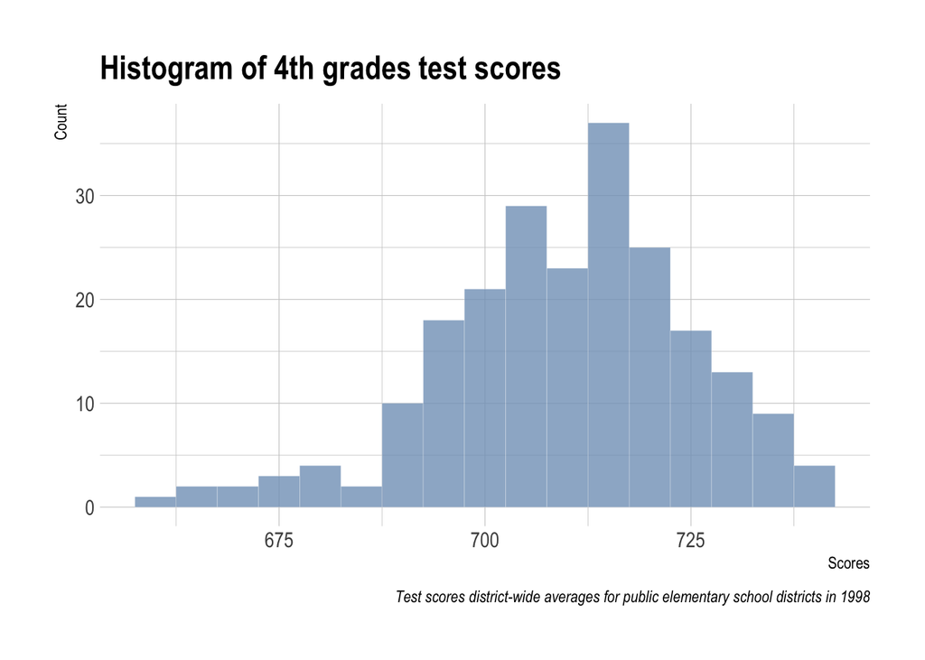

```r
ggplot(school_df, aes(x = score4)) +
  geom_histogram(binwidth = 5, color = "white", linewidth = 0.05, fill = hii, alpha = 0.8) +
  labs(
    title = "Histogram of 4th grades test scores",
    x = "Scores",
    y = "Count",
    caption = "Test scores district-wide averages for public elementary school districts in 1998"
  ) +
  hrbrthemes::theme_ipsum()
```

## Inference

Suppose we are interested in the relationship between 4th grade test scores and class room size. We specify the following model:

$$\text{Scores}_i = \beta_0 + \beta_1 \text{Class Size}_i + u_i$$

Before running any regressions,

- Write down a two tailed hypothesis test for $\beta_1$
- Briefly describe the intuition behind the argument of a hypothesis test.

*Solution*.

H0: $\beta_1 = 0$

HA: $\beta_1 \neq 0$

A hypothesis test is a statistical method where an initial claim (null hypothesis) is tested based on sample data, to see if there’s enough evidence to reject this claim in favor of an alternative hypothesis. It’s essentially deciding whether the observed differences in your sample data are due to random chance or if they reflect a meaningful, statistical difference in the broader population. In this way, the outcome space is spanned by four potential possibilities:

- Reject the null and the null is false
- Fail to reject the null and the null is true
- Type I error
- Type II error

It is always important to plot your data. Make a scatter plot of the variables in this regression. Like before, try to make it look presentable.

*Solution*.

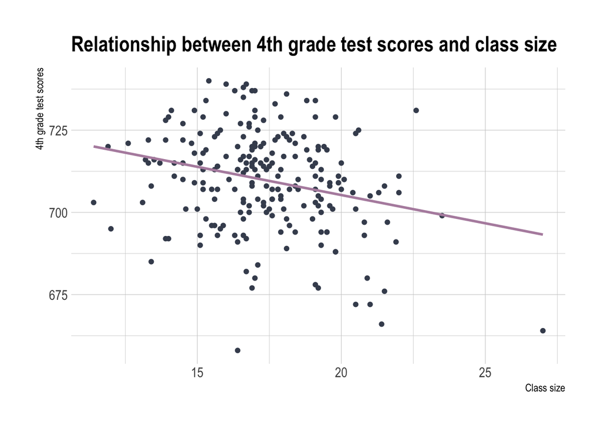

```r
ggplot(school_df, aes(x = stratio, y = score4)) +
  geom_point(color = hi) +
  geom_smooth(method = 'lm', se = FALSE, color = hp) +
  theme_ipsum() +
  labs(
    title = "Relationship between 4th grade test scores and class size",
    x = "Class size",
    y = "4th grade test scores"
  )
```

Run the above regression in R using the `lm` command. Before doing so, read the help file for the `tidy()` and `glance()` functions from the `broom` package.

- Present the output of the regression as a `tibble` using the `tidy()` function and interpret the estimates.
- Is the point estimate for $\beta_1$ statistically significant?
- What is the 95% confidence interval surrounding this estimate?
- What do we conclude with respect to our earlier hypothesis test?
- Find the $R^2$ by using the `glance()` function?
- Does class size explain a lot of the variation in test scores?

*Solution*.

```r
lm(score4 ~ stratio, school_df) %>% tidy()
```

```
# A tibble: 2 × 5
  term        estimate std.error statistic   p.value
  <chr>          <dbl>     <dbl>     <dbl>     <dbl>
1 (Intercept)   740.       7.60      97.3  1.48e-181
2 stratio        -1.72     0.435     -3.95 1.05e-  4
```

Interpretation:

- $\beta_0$: When the class size is zero, the estimated test score is $\beta_0$. I know, it doesn’t really make sense.
- $\beta_1$: For a one unit increase in class size, test scores increase by $\beta_1$.

Both estimates are statistically different from zero.

Since $\beta_1$ is statistically different than zero, we reject H0 that the coefficient is zero.

```r
glance = lm(score4 ~ stratio, school_df) %>% glance()

rsq = glance$r.squared %>% round(3)

paste0("The $R^2$ is ", rsq,".")
```

```
[1] "The $R^2$ is 0.067."
```

Describe in math, and in words, what the exogeniety assumption requires. Explain why this regression may violate this assumption.

*Solution*. The exogeniety assumption can be written as:

$$\mathrm{E}[u_i | X_i] = 0$$

In words, what this assumption requires is all potential variables lumped in the error term $u_i$ must be uncorrelated with independent variables in the regression.

This regression violates the exogeniety assumption because class size is correlated with the error term $u_i$. For example, school funding is both correlated with test scores and with class size.

What is the formula for omitted variable bias? If we were to include a variable on school funding, what would you expect the sign to be? Are we over or under estimating $\beta_1$? Explain.

*Solution*. Go easy on this question. I made a mistake in class by not managing to cover the formula for omitted variable bias before this due date super explicitly. However, they should understand some of the intuition behind whether we are over or under estimating $\beta_1$

The OVB formula is the following:

$$\text{Bias} = \beta_2 \cdot \frac{\mathrm{Cov}(X_1, X_2)}{Var(X_1)}$$

Following this formula, the bias depends on the correlation between the two $X$ variables, and the correlation of the omitted variable, $X_2$ and $Y$. The $\mathrm{Cov}(X_1, X_2) < 0$, since school funding is negatively correlated with class size (i.e., as schools spend more money, they higher more teachers, on average). Or look at the sign of funding in the following regression:

```r
lm(stratio ~ expreg, data = school_df) %>% tidy()
```

```
# A tibble: 2 × 5
  term        estimate std.error statistic  p.value
  <chr>          <dbl>     <dbl>     <dbl>    <dbl>
1 (Intercept) 23.5      0.703        33.4  8.54e-88
2 expreg      -0.00134  0.000150     -8.93 1.86e-16
```

Also, the correlation between school funding and test scores is positive (i.e., schools with more funding have higher test scores). Or see the sign of funding in the following regression

```r
lm(score4 ~ expreg, data = school_df) %>% tidy()
```

```
# A tibble: 2 × 5
  term         estimate std.error statistic   p.value
  <chr>           <dbl>     <dbl>     <dbl>     <dbl>
1 (Intercept) 696.        5.37       130.   3.02e-208
2 expreg        0.00308   0.00114      2.69 7.61e-  3
```

Thus, plugging in for our OVB formula, we find

$${\color{#BF616A} \text{Bias}} = {\color{#BF616A}\beta_2} \cdot \frac{{\color{#81A1C1} \mathrm{Cov}(X_1, X_2)}}{{\color{#81A1C1} Var(X_1)}}$$

On your old scatter plot, add another `geom` layer using `geom_smooth`. Read the help file (`?geom_smooth`) to plot the `lm` method, which is the same regression in question Q09. Do you point estimates line up with your fitted line using `geom_smooth`.

*Solution*. see above for the solution

Suppose we would like to control for school funding using in the following specification:

$$\text{Scores}_i = \beta_0 + \beta_1 \text{Class Size}_i + \text{Funding}_i + u_i$$

- Run this regression, using the variable `expreg` for school funding, and as before, interpret the coefficients and report the $R^2$.
- Does this regression improve on the $R^2$ found in the SLR above?

*Solution*.

```r
lm(score4 ~ stratio + expreg, school_df) %>% tidy()
```

```
# A tibble: 3 × 5
  term         estimate std.error statistic   p.value
  <chr>           <dbl>     <dbl>     <dbl>     <dbl>
1 (Intercept) 731.       13.1        56.0   6.37e-131
2 stratio      -1.50      0.508      -2.96  3.45e-  3
3 expreg        0.00107   0.00131     0.816 4.15e-  1
```

```r
lm(score4 ~ stratio + expreg, school_df) %>% glance()
```

```
# A tibble: 1 × 12
  r.squared adj.r.squared sigma statistic  p.value    df logLik   AIC   BIC
      <dbl>         <dbl> <dbl>     <dbl>    <dbl> <dbl>  <dbl> <dbl> <dbl>
1    0.0697        0.0611  14.7      8.13 0.000394     2  -901. 1811. 1824.
# ℹ 3 more variables: deviance <dbl>, df.residual <int>, nobs <int>
```

Based on the change in our point estimate of $\beta_2$ when we add $Funding_i$, what sign is the bias created by omitting this variable? Does this match your expectation from before?

*Solution*. Yes, this does match our intuition from before. The sign of the bias was negative. When including a control for funding, the size of the estimate is reduced.

Try to find a regression with an $R^2$ above 0.5 by adding additional regressors.

- Now find the adjusted $R^2$ (using `glance()`). Is it bigger or smaller than the standard $R^2$?

*Solution*.

```r
big_model = lm(
  score4 ~ expreg + expspecial + expbil + expocc + scratio + stratio + special + lunch + income + salary + english,
  school_df
)

tidy(big_model)
```

```
# A tibble: 12 × 5
   term           estimate  std.error statistic   p.value
   <chr>             <dbl>      <dbl>     <dbl>     <dbl>
 1 (Intercept) 723.        11.8         61.1    1.84e-119
 2 expreg       -0.00113    0.00140     -0.808  4.20e-  1
 3 expspecial   -0.0000543  0.000463    -0.117  9.07e-  1
 4 expbil       -0.0000242  0.0000289   -0.838  4.03e-  1
 5 expocc        0.0000232  0.000282     0.0823 9.35e-  1
 6 scratio      -0.102      0.237       -0.428  6.69e-  1
 7 stratio      -0.860      0.366       -2.35   1.97e-  2
 8 special      -0.318      0.188       -1.69   9.34e-  2
 9 lunch        -0.541      0.0711      -7.61   1.64e- 12
10 income        0.774      0.184        4.21   4.07e-  5
11 salary        0.213      0.276        0.773  4.40e-  1
12 english      -0.344      0.291       -1.18   2.39e-  1
```

```r
glance(big_model)
```

```
# A tibble: 1 × 12
  r.squared adj.r.squared sigma statistic  p.value    df logLik   AIC   BIC
      <dbl>         <dbl> <dbl>     <dbl>    <dbl> <dbl>  <dbl> <dbl> <dbl>
1     0.715         0.697  8.50      39.7 1.01e-41    11  -656. 1337. 1379.
# ℹ 3 more variables: deviance <dbl>, df.residual <int>, nobs <int>
```

## Footnotes

[^1]: Feel free to rename the object if you wish.
[^2]: Hint: Type `?head()` in the console.
[^3]: Hint: Read about the argument `na.rm` in the help file for the `mean` function